# The Politics of Corruption

Lecture 13: Technology Against Corruption — Open Data and AI

Bogdan G. Popescu

bgpopescu@tec.mx

Tecnológico de Monterrey

## Today

**Can technology expose or prevent corruption?** The claim defended here:

> Technology improves monitoring only when someone has both the **incentive** and the **power** to act on what it reveals.
- **Europe:** information nobody can act on changes little
- **Mexico:** algorithms sharpen targeting; humans still decide
- **China:** whoever controls the tool may want something else

#### By the end you should be able to

1. Describe two deployed anticorruption technologies and their measured impact
2. Explain two ways such technology fails, including authoritarian use

## Start where the money is

- Governments buy goods and services from private firms
- This is called **public procurement**: roads, medicines, software
- It is 12–29% of government spending in OECD countries
- Transparency International estimates 10–15% is lost to corruption
- Every purchase leaves a written record

> Procurement is the best test case: high stakes, and unusually good data.

Figures as reported in Medina-Hernández, Kertész and Fazekas (2026), citing OECD (2016) and Transparency International.

# I. Why technology should help

Image: server room, BalticServers.com, CC BY-SA 3.0, via Wikimedia Commons.

## Two stories about sunlight

#### Story 1: the watchdog problem

Citizens hire officials to act for them, but cannot see what they do. Publish the information and the watchdog can finally bite.

#### Story 2: the everybody-does-it problem

Officials and firms follow what they expect others to do. Information only helps if enough people change their expectations together.

The first story predicts that data alone works. The second predicts it does not.

Framing follows Adam and Fazekas (2021), who review both perspectives.

## Two ways in, one bottleneck

```
%%{init: {"theme":"base","htmlLabels":false,"flowchart":{"useMaxWidth":true,"htmlLabels":false,"wrappingWidth":420,"nodeSpacing":110,"rankSpacing":65,"curve":"basis"},"themeVariables":{"fontSize":"22px","fontFamily":"Arial, Helvetica, sans-serif","lineColor":"#334155","primaryColor":"#eef2f5","prima…
flowchart LR
  T["Digital tool<br/>open data or<br/>algorithm"]
  A["Disclosure<br/>rivals and citizens<br/>can see the deal"]
  B["Targeting<br/>investigators learn<br/>where to look"]
  H["Someone with power<br/>acts on what<br/>they can now see"]
  O["Corruption becomes<br/>riskier or<br/>simply harder"]
  T --> A --> H
  T --> B --> H
  H --> O
  classDef tool fill:#4a7c6f,stroke:#2f5349,stroke-width:2px,color:#ffffff;
  classDef mid fill:#eef2f5,stroke:#334155,stroke-width:1.5px,color:#1e293b;
  classDef gate fill:#b7943a,stroke:#7d6222,stroke-width:2.5px,color:#1e293b;
  classDef out fill:#b44527,stroke:#7d2f1a,stroke-width:2px,color:#ffffff;
  class T tool; class A,B mid; class H gate; class O out;
```

Framework adapted from Adam and Fazekas (2021). Everything that follows turns on the gold box.

## So what?

Two routes into the same problem: **show people the deal**, or **tell investigators where to look**.

Both run through the same bottleneck — someone able and willing to act.

Next: test the first route. What happens when a government publishes more?

# II. Open contracting and red flags

## Every tender leaves a trail

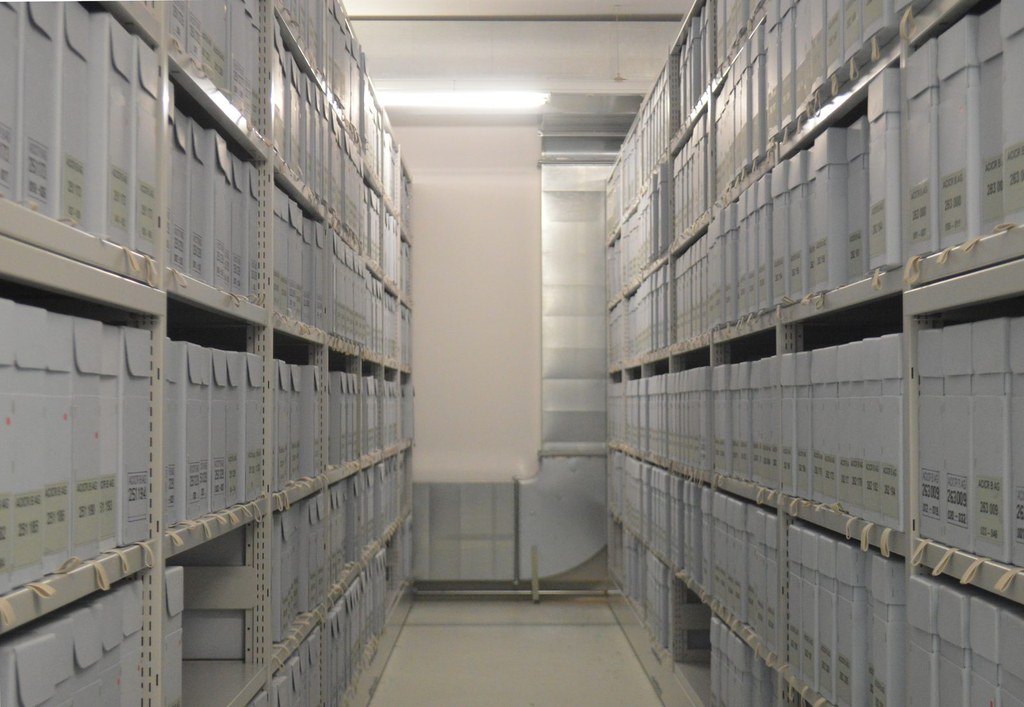

Public archive shelves at the International Committee of the Red Cross, Geneva.

Photo: Roman Deckert, 2020, CC BY-SA 4.0, via Wikimedia Commons. Records become auditable only once they are machine-readable.

## What a suspicious contract looks like

Contract-level warning signs used in corruption risk indices

| Warning sign | Why it is suspicious |
| --- | --- |
| Only one company bids | Competition may have been steered away |
| No call for tenders published | Rivals never learned the contract existed |
| Non-open procedure used | The buyer chose who was allowed to bid |
| Very short advertisement period | Only a pre-warned firm could prepare |
| Unusual price or quantity patterns | Figures look constructed rather than costed |

Researchers call these **red flags**. Combined, they form a *corruption risk index*. They measure **risk, not guilt**: a flagged contract may be entirely lawful.

Source: Fazekas, Tóth and King (2016); indicator list as summarised in Medina-Hernández et al. (2026).

## Does publishing more actually help?

- 3.5 million European contracts, awarded 2006–2015
- Outcome: **single bidding**, a corruption *risk* indicator
- Treatment: how many required items the buyer publishes
- Information released **before** and **after** the award, separately
- Buyer fixed effects: each organisation compared with itself
- Still observational: this is association, not an experiment

> Single-bidder contracts are on average **7.1% more expensive**.

Source: Bauhr, Czibik, de Fine Licht and Fazekas (2020).

## Timing beats volume

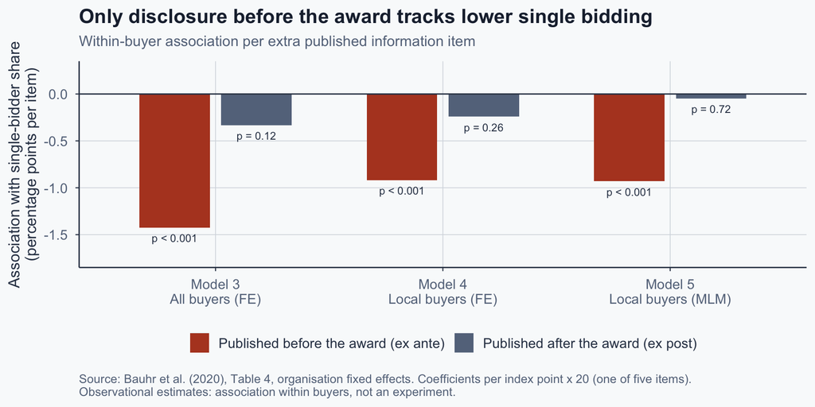

Why timing matters: **rival bidders** can still object before the award; citizens and journalists read the file once the money is already spent.

Insiders monitoring insiders is called *horizontal* accountability (Bauhr et al., 2020).

## Published, but not usable

- Reviews find “open” data is often hard to find
- Files are scans, not machine-readable records
- Licences are unclear, so reuse is legally risky
- Publishing satisfies the rule without enabling scrutiny

What matters is not *how much* is published, but *whether the right people can use it in time*.

Source: Adam and Fazekas (2021), reviewing studies of government transparency portals.

## Exercise 1: fund one reform

Your city already publishes the winner and the price of every contract. Corruption complaints have not fallen. You can fund **one** reform.

1. Publish full award criteria and deadlines **before** bidding opens
2. Fund an independent appeals office where losing bidders can complain
3. Automatically flag every single-bid tender for review

**In pairs:** choose one and defend it. Then name the single fact about your city’s politics that would **reverse** your choice.

Estimated time: 5 minutes (3 discuss, 2 report back)

## So what?

Disclosure is associated with less corruption risk — but only the kind that reaches people who can object in time, and only where the data is usable.

That is a great deal of human reading for a modest gain.

Next: can a machine do the reading for us?

# III. Machine learning in Mexico

## The problem with training a detector

- To learn “suspicious”, a model normally needs clean examples too
- We have some contracts linked to sanctioned firms
- We have **no** contract certified as honest
- Unflagged contracts are unknown, not innocent
- Treating them as innocent teaches the model the wrong lesson

Learning from confirmed positives plus unknowns is called **positive–unlabeled learning**.

Source: Medina-Hernández, Kertész and Fazekas (2026).

## The Mexican evidence base

Data behind the Mexican fraud-detection model

| Ingredient | What it contains |
| --- | --- |
| Contracts (CompraNet, 2011–2022) | 2,301,278 federally funded contracts |
| Buyers | 5,304 government entities |
| Suppliers | 259,534 private companies |
| Sanction lists (SAT and SFP) | 14,535 sanctioned companies |
| Sanctioned firms found in contracts | 1,673 |
| Contracts labelled suspicious | 2.2–5% per year |

Source: Medina-Hernández et al. (2026). Sanctions issued by the tax authority (SAT) and the public administration ministry (SFP), both independent of the buyers.

## How much better than guessing?

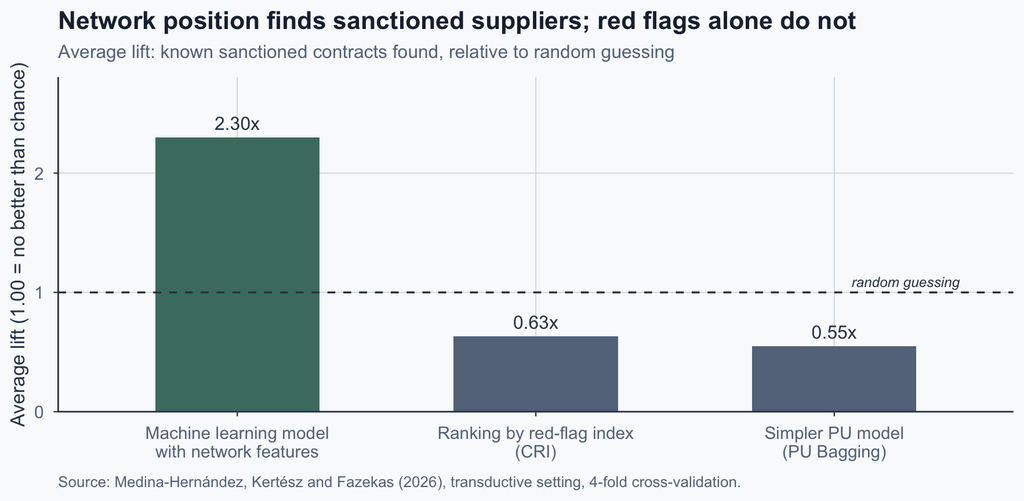

## From sanctions to a work queue

```
%%{init: {"theme":"base","htmlLabels":false,"flowchart":{"useMaxWidth":true,"htmlLabels":false,"wrappingWidth":420,"nodeSpacing":130,"rankSpacing":50,"curve":"basis"},"themeVariables":{"fontSize":"21px","fontFamily":"Arial, Helvetica, sans-serif","lineColor":"#334155","primaryColor":"#eef2f5","prima…
flowchart LR
  S["Sanction lists<br/>1,673 firms<br/>found in contracts"] --> L["Label their<br/>contracts as<br/>known positives"]
  C["2.3 million<br/>contracts"] --> F["Features:<br/>red flags plus<br/>network position"]
  L --> M["Positive-unlabeled<br/>model"]
  F --> M
  M --> R["Contracts ranked<br/>most suspicious first"]
  R --> A["Human audit<br/>and prosecution"]
  classDef data fill:#eef2f5,stroke:#334155,stroke-width:1.5px,color:#1e293b;
  classDef model fill:#4a7c6f,stroke:#2f5349,stroke-width:2px,color:#ffffff;
  classDef out fill:#b44527,stroke:#7d2f1a,stroke-width:2px,color:#ffffff;
  class S,C,L,F data; class M model; class R,A out;
```

Source: Medina-Hernández et al. (2026). The output is a priority list, not a verdict.

## Read the result honestly

- 2.3× better than chance is useful, not decisive
- The model ranks contracts; humans still decide guilt
- Labels are sanctions, and sanctions follow audits
- Open tenders get audited more than direct awards
- Sophisticated corruption is often formally legal, so unflagged
- So the model partly learns *where investigators already look*

> A detector trained on past enforcement inherits the blind spots of past enforcement.

Source: Medina-Hernández et al. (2026), discussion of label bias by procedure type. The score is a hypothesis about whom to investigate, never a finding.

## So what?

Both deployments help at the margin. Neither convicts anyone; both end at a human decision.

We have assumed all along that **the state wants less corruption**.

Next: drop that assumption. Who else can use these tools, and against whom?

# IV. When the state is the problem

Image: Utah Data Center, Bluffdale, Utah. Photo: Swilsonmc, CC BY-SA 3.0, via Wikimedia Commons.

## Discretion moves; it does not disappear

- Cryptocurrencies and the dark web move payments out of sight
- Digital systems can be manipulated from the inside
- Croatian tollbooths lost about €2 million yearly to false entries
- One central database concentrates power in few hands

Digitalisation does not remove discretion. It **relocates** it — usually toward whoever runs the system.

Source: Adam and Fazekas (2021), citing ReSPA (2013) for the Croatian case.

## The same tools, a different buyer

[figure not shown]

Facial-recognition gates at Xietang station, Suzhou metro, China (2024).

Photo: Shwangtianyuan, 2024, CC BY-SA 4.0, via Wikimedia Commons.

## AI-tocracy: a loop, not a tool

```
%%{init: {"theme":"base","htmlLabels":false,"flowchart":{"useMaxWidth":true,"htmlLabels":false,"wrappingWidth":420,"nodeSpacing":110,"rankSpacing":70,"curve":"basis"},"themeVariables":{"fontSize":"22px","fontFamily":"DM Sans, Segoe UI, sans-serif","lineColor":"#334155","primaryColor":"#eef2f5","prim…
flowchart LR
  U["Local protest<br/>or unrest"]
  P["Public security buys<br/>facial-recognition AI"]
  S["Later unrest<br/>is suppressed"]
  F["Contracted firms<br/>build more software"]
  E["Products good<br/>enough to export"]
  U -->|"next quarter"| P
  P --> S
  P --> F
  F --> E
  S -->|"loop 1: control"| U
  E -->|"loop 2: innovation"| P
  classDef unrest fill:#b7943a,stroke:#7d6222,stroke-width:2px,color:#1e293b;
  classDef proc fill:#b44527,stroke:#7d2f1a,stroke-width:2px,color:#ffffff;
  classDef firm fill:#4a7c6f,stroke:#2f5349,stroke-width:2px,color:#ffffff;
  class U,S unrest; class P proc; class F,E firm;
```

Source: Beraja, Kao, Yang and Yuchtman (2023). Both arrows back are estimated, not assumed.

## Who buys the algorithms?

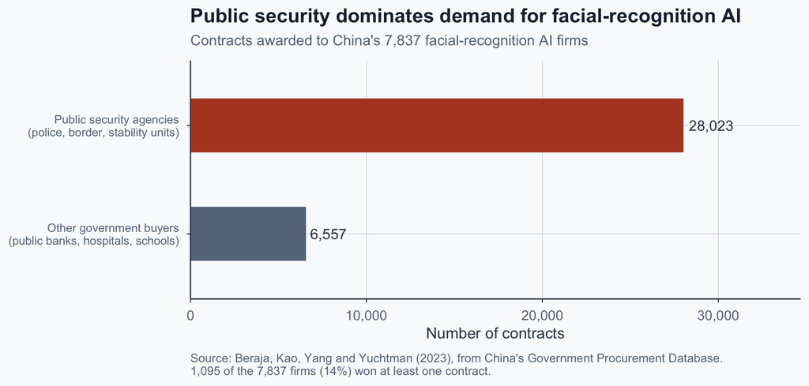

Beraja and colleagues read this demand as political control: purchases rise in the quarter *after* local unrest.

## Exercise 2: red-team the risk model

Mexico’s model works. A ministry now proposes a **national contract risk-scoring system**, with scores published monthly.

**In pairs, name one item for each:**

1. One group likely to be **wrongly flagged**, and why the data does that
2. One way a government could **misuse** the scores for political ends
3. One safeguard that would make you support the system

Estimated time: 5 minutes (3 discuss, 2 report back)

## Three propositions to take away

Europe (Bauhr), Mexico (Medina-Hernández), China (Beraja)

| Proposition | Where we saw it |
| --- | --- |
| Information works only when someone can act on it | Only pre-award disclosure tracks lower single bidding |
| Algorithms prioritise suspicion; they never establish guilt | 2.3x better than chance, on enforcement-shaped labels |
| Technology inherits the incentives of whoever deploys it | Unrest raises AI purchases; AI then dampens unrest |

> Technology augments monitoring. It never substitutes for politics.

## References

Adam, I., & Fazekas, M. (2021). Are emerging technologies helping win the fight against corruption? A review of the state of evidence. *Information Economics and Policy*, *57*, 100950. https://doi.org/10.1016/j.infoecopol.2021.100950

Bauhr, M., Czibik, Á., de Fine Licht, J., & Fazekas, M. (2020). Lights on the shadows of public procurement: Transparency as an antidote to corruption. *Governance*, *33*(3), 495–523. https://doi.org/10.1111/gove.12432

Beraja, M., Kao, A., Yang, D. Y., & Yuchtman, N. (2023). AI-tocracy. *The Quarterly Journal of Economics*, *138*(3), 1349–1402. https://doi.org/10.1093/qje/qjad012

Fazekas, M., Tóth, I. J., & King, L. P. (2016). An objective corruption risk index using public procurement data. *European Journal on Criminal Policy and Research*, *22*(3), 369–397. https://doi.org/10.1007/s10610-016-9308-z

Medina-Hernández, M., Kertész, J., & Fazekas, M. (2026). Learning from sanctioned government suppliers: A machine learning and network science approach to detecting fraud and corruption in Mexico. *Scientific Reports*, *16*(1), 22382. https://doi.org/10.1038/s41598-026-48873-w

## Image credits

BalticServers.com. (2013). *Server room of BalticServers* [Photograph]. Wikimedia Commons. CC BY-SA 3.0. https://commons.wikimedia.org/wiki/File:BalticServers_data_center.jpg

Deckert, R. (2020). *Shelves with file folders in the repository of the public archives at the ICRC headquarters in Geneva* [Photograph]. Wikimedia Commons. CC BY-SA 4.0. https://commons.wikimedia.org/wiki/File:CICR-ICRC-PublicArchives_HQ-Geneva_RomanDeckert09062020.jpg

Shwangtianyuan. (2024). *Facial recognition gate at Xietang station (Line 8)* [Photograph]. Wikimedia Commons. CC BY-SA 4.0. https://commons.wikimedia.org/wiki/File:Facial_recognition_gate_at_Xietang_station_(Line_8)-20240910.jpg

Swilsonmc. (2013). *Utah Data Center panorama* [Photograph]. Wikimedia Commons. CC BY-SA 3.0. https://commons.wikimedia.org/wiki/File:Utah_Data_Center_Panorama_(cropped).jpg